# Tom’s Statistics and Data Science Toolkit (tsdst)

Version 1.0.11

Tom Werner

Last Updated: 30 July 2021

# 1 Introduction

This document covers all the functions, classes, and methods contained in the `tsdst` package. It is organized in alphabetical order, first by module name, and then by object name. Many of the methods discussed have general uses, however, most of the examples will be directly related to the reliability of mechanical systems. This document assumes a basic knowledge Bayesian Probability Theory. For more info, see the following [Wikipedia article.](https://en.wikipedia.org/wiki/Bayes%27_theorem)

# 2 The Package

## 2.1 tsdst.distributions

This section contains statistical functions for various distributions for a wide range of purposes.

### 2.1.1 General Functions

#### 2.1.1.1 dpoibin_exact

The probability mass function for the poisson-binomial distribution.

This function is adapted from Mark Lodato of StackExchange, Nov 7’16. It’s fast, but runs slower than 1 second once `len(p) > 25000`. Computes both the pdf and the cdf. See (Hong 2013) or (Lodato 2016) for more information.

Adapted to compute both the pdf and the cdf.

```
Parameters
----------
k : numpy array or int
    Poisson counts.
p : numpy array or float
    Binomial probabilities.
cdf : bool, optional
    Compute the cdf. Default is False.

Returns
-------
karray : float or numpy array
    The mass of the poisson-binomial distribution.
```

```python
import numpy as np
from tsdst.distributions import dpoibin_exact

p = np.array([0.5,0.975, 0.3])
k = np.array([2, 3])

print(dpoibin_exact(k, p, cdf=False))
```

```
[0.49125 0.14625]
```

```python
print(dpoibin_exact(k, p, cdf=True))
```

```
[0.85375 1.     ]
```

#### 2.1.1.2 dpoibin_FT

The probability mass function for the poisson-binomial distribution. This function is written by the author of this package, and uses the discrete fourier transform.

```
Parameters
----------
k : numpy array or int
    Poisson counts.
p : numpy array or float
    Binomial probabilities.

Returns
-------
karray : float or numpy array
    The mass of the poisson-binomial distribution.
```

```python
import numpy as np
from tsdst.distributions import dpoibin_FT

p = np.array([0.5,0.975, 0.3])
k = np.array([2, 3])

dpoibin_FT(k, p)
```

```
array([0.49125, 0.14625])
```

#### 2.1.1.3 dpoibin_PA

Poisson approximation of the Poisson-Binomial probability mass function. Fast, but possibly inaccurate.

```
Parameters
----------
k : numpy array or int
    The poisson counts.
p : numpy array or float
    Binomial probabilities.

Returns
-------
prob : float
    The mass of the poisson-binomial distribution.
```

```python
import numpy as np
from tsdst.distributions import dpoibin_PA

p = np.array([0.5,0.975, 0.3])
k = np.array([2, 3])

dpoibin_PA(k, p)
```

```
array([0.2669894 , 0.15796873])
```

#### 2.1.1.4 dwrap

- weibull
- exponential
- log-normal (lnorm)
- normal (norm)
- gamma

I have found that writing the distributions in plain math is sometimes faster in python than using the scipy implementations, which is why this function originally existed. I wrote my own versions of the distributions, except where the distributions were complicated and it wasn’t worth it at the time (and then this function uses scipy). However, as time goes on, that will probably change. Also, the scipy.stats implementations and documentations are quite complete, so unless you’re feeling adventurous, it’s probably a good idea to just use [scipy](https://docs.scipy.org/).

```
Parameters
----------
data : numpy array or pandas dataframe/series
    Numeric values representing the data of interest, either a random
    variable, probability, or quantile.
params : numpy array or pandas dataframe/series
    the parameters of the function of interest (shape, scale, etc.)
    - weibull: (shape, scale)
    - exponential: (rate,)
    - lnorm: (mu, sigma)
    - normal: (mu, sigma)
    - gamma: (shape, scale)
disttype : str
    the distribution type, which currently includes pdf, cdf, inv-cdf, sf,
    left-truncated-cdf, left-truncated-inv-cdf. (Note: not all of these
    options may be available for all funct options)
funct : str
    the distribution function, which currently includes weibull,
    exponential, log-normal (as lnorm), normal, and gamma
log : bool, optional
    Whether to use the log of the distribution or not. The default is
    False.

Raises
------
ValueError
    Raised when invalid distribution type or function is chosen.

Returns
-------
numpy array
    an array containing the evaluation of the distribution.
```

```python
import numpy as np
from tsdst.distributions import dwrap

data = np.array([0.5,0.975])
params = np.array([0, 1])
dwrap(data, params, disttype="inv-cdf", funct="normal", log=False)
```

```
array([0.        , 1.95996398])
```

#### 2.1.1.5 pnorm_approx

This is a fast approximation of the normal cdf, accurate to 1.5e-7. For exact solutions, use dwrap or SciPy.

```
Parameters
----------
q : float
    Quantile of interest.
mu : float, optional
    Mean of the normal distribution. The default is 0.
sigma : float, optional
    Standard deviation of the normal distribution. The default is 1.
lt : bool, optional
    Use lower tail. The default is True.
log : bool, optional
    Return log of the value. The default is False.

Returns
-------
prob : float
    The probability at the given quantile.
```

```python
import numpy as np
from tsdst.distributions import pnorm_approx

data = np.array([0, 1.96])
params = np.array([0, 1])

pnorm_approx(q=data, mu=0, sigma=1, lt=True, log=False)
```

```
array([0.5       , 0.97500217])
```

#### 2.1.1.6 ppoibin_RNA

Refined normal approximation of Poisson-Binomial Cumulative Distribution. This code is adapted from the R package ‘poibin.’ Very fast for len(p) > 10000.

```
Parameters
----------
k : numpy array or int
    Poisson counts.
p : numpy array or float
    Binomial probabilities.
p_weight : numpy array, optional
    Weights for the probabilities. Same length as p. The default is None.

Returns
-------
vkk_r : numpy array or float
    cumulative probabilities.
```

```python
import numpy as np
from tsdst.distributions import ppoibin_RNA

p = np.array([0.5,0.975, 0.3])
k = np.array([2, 3])

ppoibin_RNA(k, p, p_weight=None)
```

```
array([0.85063305, 0.99054359])
```

#### 2.1.1.7 qnorm_aprox

This is a fast approximation of the normal quantile function, or inverse cdf. Accurate to 2 or 3 digits. For exact solutions, use dwrap or SciPy.

```
Parameters
----------
p : float or array-like
    percentile (or probability) of interest.
mu : float, optional
    Mean of the normal distribution. The default is 0.
sigma : float, optional
    Standard deviation of the normal distribution. The default is 1.
lt : bool, optional
    Lower tail of the distribution. The default is True.

Returns
-------
quant : float or numpy array
    Return quantile of interest.
```

```python
import numpy as np
from tsdst.distributions import qnorm_aprox

data = np.array([0.5,0.975])

qnorm_aprox(p=data, mu=0, sigma=1, lt=True)
```

```
array([0.        , 1.95904894])
```

### 2.1.2 Likelihood Functions

#### 2.1.2.1 likelihood_bernoulli

The likelihood for a binary output or bernoulli model

```
Parameters
----------
y_true : numpy array (numeric)
    The true values (the binary observations).
y_score : numpy array or pandas dataframe
    The predicted probabilities.
neg : bool, optional
    Return negative likelihood. The default is True.
log : bool, optional
    Return log-likelihood. The default is True.

Returns
-------
float
    The likelihood.
```

#### 2.1.2.2 likelihood_gaussian

The likelihood for a normal(ish) output or gaussian model

```
Parameters
----------
y_true : numpy array (numeric)
    The true values (the normal observations).
y_score : numpy array or pandas dataframe
    The estimated value/values (mean of the normal distribution).
neg : bool, optional
    Return negative likelihood. The default is True.
log : bool, optional
    Return log-likelihood. The default is True.

Returns
-------
float
    The likelihood.
```

#### 2.1.2.3 likelihood_poisson

The likelihood for a count output or poisson model

```
Parameters
----------
y_true : numpy array (numeric)
    The true values (the poisson observations).
y_score : numpy array or pandas dataframe
    The estimated value/values (lambda).
neg : bool, optional
    Return negative likelihood. The default is True.
log : bool, optional
    Return log-likelihood. The default is True.

Returns
-------
float
    The likelihood.
```

#### 2.1.2.4 glm_likelihood_bernoulli

The likelihood for a logistic regression or bernoulli model with a penalty term (can accept any norm, default is 1 for L1).

```
Parameters
----------
parms : numpy array (numeric)
    The coefficients (including intercept, which is first)
X : numpy array (numeric)
    The independent variables (or feature matrix), where the first column
    is a dummy column of 1's (for the intercept).
Y : numpy array or pandas dataframe
    The response value (should be 0 or 1, but could be float as well if
    you're willing to deal with those consequences).
lamb : int, optional
    The size of the penalty (lambda). Note this is the inverse of the
    common sklearn parameter C (i.e. C=1/lambda. The default is 1.
l_p : int, optional
    The mathmatical norm to be applied to the coefficients.
    The default is 1, representing an L1 penalty.
neg : bool, optional
    Return negative likelihood. The default is True.
log : bool, optional
    Return log-likelihood. The default is True.

Returns
-------
float
    The negative log-likelihood.
```

```python
import numpy as np
from tsdst.distributions import glm_likelihood_bernoulli

intercept = np.array([3])
betas = np.array([2,4,5])

params = np.concatenate((intercept, betas))
np.random.seed(123)
X = np.random.normal(size=(100, 3))
X = np.hstack((np.repeat(1, 100).reshape(-1, 1), X))
Y = np.round(np.random.uniform(low=0, high=1, size=100))

glm_likelihood_bernoulli(params, X, Y, lamb=1, l_p=1)
```

```
386.6152600787893
```

#### 2.1.2.5 glm_likelihood_gaussian

The likelihood for a gaussian regression model with a penalty term (can accept any norm, default is 1 for L1)

```
Parameters
----------
parms : numpy array (numeric)
    The coefficients (including intercept, which is first)
X : numpy array (numeric)
    The independent variables (or feature matrix), where the first column
    is a dummy column of 1's (for the intercept).
Y : numpy array or pandas dataframe
    The response value (should be 0 or 1, but could be float as well if
    you're willing to deal with those consequences).
lamb : int, optional
    The size of the penalty (lambda). Note this is the inverse of the
    common sklearn parameter C (i.e. C=1/lambda. The default is 1.
l_p : int, optional
    The mathmatical norm to be applied to the coefficients.
    The default is 1, representing an L1 penalty.
neg : bool, optional
    Return negative likelihood. The default is True.
log : bool, optional
    Return log-likelihood. The default is True.

Returns
-------
float
    The negative log-likelihood.
```

```python
import numpy as np
from tsdst.distributions import glm_likelihood_gaussian

intercept = np.array([3])
betas = np.array([2,4,5])

params = np.concatenate((intercept, betas))
np.random.seed(123)
X = np.random.normal(size=(100, 3))
X = np.hstack((np.repeat(1, 100).reshape(-1, 1), X))
Y = np.random.normal(size=100)

glm_likelihood_gaussian(params, X, Y, lamb=1, l_p=1)
```

```
360.17670995853115
```

#### 2.1.2.6 glm_likelihood_poisson

The likelihood for a poisson regression model with a penalty term (can accept any norm, default is 1 for L1)

```
Parameters
----------
parms : numpy array (numeric)
    The coefficients (including intercept, which is first)
X : numpy array (numeric)
    The independent variables (or feature matrix), where the first column
    is a dummy column of 1's (for the intercept).
Y : numpy array or pandas dataframe
    The response value (should be 0 or 1, but could be float as well if
    you're willing to deal with those consequences).
lamb : int, optional
    The size of the penalty (lambda). Note this is the inverse of the
    common sklearn parameter C (i.e. C=1/lambda. The default is 1.
l_p : int, optional
    The mathmatical norm to be applied to the coefficients.
    The default is 1, representing an L1 penalty.
neg : bool, optional
    Return negative likelihood. The default is True.
log : bool, optional
    Return log-likelihood. The default is True.

Returns
-------
float
    The negative log-likelihood.
```

```python
import numpy as np
from tsdst.distributions import glm_likelihood_poisson

intercept = np.array([3])
betas = np.array([2,4,5])

params = np.concatenate((intercept, betas))
np.random.seed(123)
X = np.random.normal(size=(100, 3))
X = np.hstack((np.repeat(1, 100).reshape(-1, 1), X))
Y = np.round(np.random.uniform(low=0, high=10, size=100))

glm_likelihood_poisson(params, X, Y, lamb=1, l_p=1)
```

```
3287063650.908373
```

#### 2.1.2.7 ExactMLE_exp

Calculates the exact solution to the maximum likelihood of the exponential distribution (see Appendix for more details). This function also allows for type I right-censored data. The `censored` variable is defined as whether the data was successfully observed or not. For example, if a failure occurred for a certain data point, then `censored=1`, otherwise if no failure was observed, `censored=0`. Therefore, `censored` is an array of 1s and 0s.

```
Parameters
----------
data : numpy array
    The data for the exponential distribution (usually time between events,
    or similar).
censored : numpy array
    An array of boolean values where 1 means the event occured and 0 means
    the event is censored (right).

Returns
-------
list
    A list containing (in order) the MLE, the standard error, and the
    95% confidence interval for the estimate.
```

```python
ExactMLE_exp(data, censored)
```

### 2.1.3 Posterior Functions

#### 2.1.3.1 posterior_logreg_lasso

The posterior density for a logistic regression model with an L1 penalty term.

```
Parameters
----------
parms : numpy array (numeric)
    The coefficients (including intercept, which is first)
X : numpy array (numeric)
    The independent variables (or feature matrix), where the first column
    is a dummy column of 1's (for the intercept).
Y : numpy array or pandas dataframe
    The response value (should be 0 or 1, but could be float as well if
    you're willing to deal with those consequences).
l_scale : float, optional
    The value of the scale parameter in the Laplace distribution.
    A common choice for the laplace prior is scale = 2/lambda,
    because it can be shown that this is the MAP estimate where
    a laplace prior is equivalent to performing lasso regression.
    lambda is the L1 penalty, or scale = 2*C (where C is the penalty term
    in sklearn).

    I find that when scale == C, you get more similar results to
    the model output in sklearn, and based on
    my research into their implementation, I think it is because the
    sklearn implementation actually scales lambda by 1/2 (see the user
    guide (here)[https://scikit-learn.org/stable/modules/linear_model.html] for more details),
    but i'm not 100% sure on this. This parameterization is similar to
    scale = stddev/lambda or scale = stddev*C, where they set stddev to
    1 instead of 2. The default value is 1.
neg : bool, optional
    Return negative density. The default value is False.
log : bool, optional
    Return log-density. The default value is True.

Returns
-------
float
    The posterior density (height of the posterior density)
```

```python
import numpy as np
from tsdst.distributions import posterior_logreg_lasso

intercept = np.array([3])
betas = np.array([2,4,5])

params = np.concatenate((intercept, betas))
np.random.seed(123)
X = np.random.normal(size=(100, 3))
X = np.hstack((np.repeat(1, 100).reshape(-1, 1), X))
Y = np.round(np.random.uniform(low=0, high=1, size=100))

posterior_logreg_lasso(params, X, Y)
```

```
-400.881783704988
```

#### 2.1.3.2 ap_logreg_lasso

The adaptive posterior density for a logistic regression model with an L1 penalty term. However, unlike the posterior_logreg_lasso function, this is made to addaptively learn the optimal L1 penalty. Therefore, the L1 penalty is in the parms variable, at the end of the array

```
Parameters
----------
parms : numpy array (numeric)
    The model coefficients (including intercept, which is first, and the
    scale of the laplace distribution, which is last)
X : numpy array (numeric)
    The independent variables (or feature matrix), where the first column
    is a dummy column of 1's (for the intercept).
Y : numpy array or pandas dataframe
    The response value (should be 0 or 1, but could be float as well if
    you're willing to deal with those consequences).
l_scale : float, optional
    ---THIS IS NOT USED. ONLY HERE FOR CONVENIENCE OF THE USER WHEN
    EXPERIMENTING BETWEEN THE ADAPTIVE AND NON-ADAPTIVE VERSIONS---
    The value of the scale parameter in the Laplace distribution.
    A common choice for the laplace prior is scale = 2/lambda,
    because it can be shown that this is the MAP estimate where
    a laplace prior is equivalent to performing lasso regression.
    lambda is the L1 penalty, or scale = 2*C (where C is the penalty term
    in sklearn).

    I find that when scale == C, you get more similar results to
    the model output in sklearn, and based on
    my research into their implementation, I think it is because the
    sklearn implementation actually scales lambda by 1/2 (see the user
    guide (here)[https://scikit-learn.org/stable/modules/linear_model.html] for more details),
    but i'm not 100% sure on this. This parameterization is similar to
    scale = stddev/lambda or scale = stddev*C, where they set stddev to
    1 instead of 2. The default value is 1.
neg : bool, optional
    Return negative density. The default value is False.
log : bool, optional
    Return log-density. The default value is True.

Returns
-------
float
    The posterior density (height of the posterior density)
```

```python
import numpy as np
from tsdst.distributions import ap_logreg_lasso

intercept = np.array([3])
betas = np.array([2,4,5])
scale_param = np.array([1])

params = np.concatenate((intercept, betas, scale_param))
np.random.seed(123)
X = np.random.normal(size=(100, 3))
X = np.hstack((np.repeat(1, 100).reshape(-1, 1), X))
Y = np.round(np.random.uniform(low=0, high=1, size=100))

ap_logreg_lasso(params, X, Y)
```

```
-395.3461032130849
```

#### 2.1.3.3 ap_poisson_lasso

The adaptive posterior density for a poisson regression model with an L1 penalty term. However, unlike the poisson_regression function, this is made to adaptively learn the optimal L1 penalty. Therefore, the L1 penalty is in the `parms` variable, at the end of the array

```
Parameters
----------
parms : numpy array (numeric)
    The model coefficients (including intercept, which is first, and the
    scale of the laplace distribution, which is last)
X : numpy array (numeric)
    The independent variables (or feature matrix), where the first column
    is a dummy column of 1's (for the intercept).
Y : numpy array or pandas dataframe
    The response value (should be 0 or 1, but could be float as well if
    you're willing to deal with those consequences).
l_scale : float, optional
    ---THIS IS NOT USED. ONLY HERE FOR CONVENIENCE OF THE USER WHEN
    EXPERIMENTING BETWEEN THE ADAPTIVE AND NON-ADAPTIVE VERSIONS---
    The value of the scale parameter in the Laplace distribution.
    A common choice for the laplace prior is scale = 2/lambda,
    because it can be shown that this is the MAP estimate where
    a laplace prior is equivalent to performing lasso regression.
    lambda is the L1 penalty, or scale = 2*C (where C is the penalty term
    in sklearn).

    I find that when scale == C, you get more similar results to
    the model output in sklearn, and based on
    my research into their implementation, I think it is because the
    sklearn implementation actually scales lambda by 1/2 (see the user
    guide (here)[https://scikit-learn.org/stable/modules/linear_model.html] for more details),
    but i'm not 100% sure on this. This parameterization is similar to
    scale = stddev/lambda or scale = stddev*C, where they set stddev to
    1 instead of 2. The default value is 1.
neg : bool, optional
    Return negative density. The default value is False.
log : bool, optional
    Return log-density. The default value is True.

Returns
-------
float
    The posterior density (height of the posterior density)
```

```python
import numpy as np
from tsdst.distributions import ap_poisson_lasso

intercept = np.array([3])
betas = np.array([2,4,5])
scale_param = np.array([1])

params = np.concatenate((intercept, betas, scale_param))
np.random.seed(123)
X = np.random.normal(size=(100, 3))
X = np.hstack((np.repeat(1, 100).reshape(-1, 1), X))
Y = np.round(np.random.uniform(low=0, high=10, size=100))

ap_poisson_lasso(params, X, Y)
```

```
-3287063657.162545
```

#### 2.1.3.4 ap_poisson_lasso_od

The posterior density for a poisson regression model with an L1 penalty term. However, unlike the poisson_regression function, this is made to addaptively learn the optimal L1 penalty. Therefore, the L1 penalty is in the parms variable, at the end of the array. This function also attempts to adaptively account for overdispersion (See Appendix for more details).

```
Parameters
----------
parms : numpy array (numeric)
    The model coefficients (including intercept, which is first, and the
    scale of the laplace distribution, which is last)
X : numpy array (numeric)
    The independent variables (or feature matrix), where the first column
    is a dummy column of 1's (for the intercept).
Y : numpy array or pandas dataframe
    The response value (should be 0 or 1, but could be float as well if
    you're willing to deal with those consequences).
l_scale : float, optional
    ---THIS IS NOT USED. ONLY HERE FOR CONVENIENCE OF THE USER WHEN
    EXPERIMENTING BETWEEN THE ADAPTIVE AND NON-ADAPTIVE VERSIONS---
    The value of the scale parameter in the Laplace distribution.
    A common choice for the laplace prior is scale = 2/lambda,
    because it can be shown that this is the MAP estimate where
    a laplace prior is equivalent to performing lasso regression.
    lambda is the L1 penalty, or scale = 2*C (where C is the penalty term
    in sklearn).

    I find that when scale == C, you get more similar results to
    the model output in sklearn, and based on
    my research into their implementation, I think it is because the
    sklearn implementation actually scales lambda by 1/2 (see the user
    guide (here)[https://scikit-learn.org/stable/modules/linear_model.html] for more details),
    but i'm not 100% sure on this. This parameterization is similar to
    scale = stddev/lambda or scale = stddev*C, where they set stddev to
    1 instead of 2. The default value is 1.
neg : bool, optional
    Return negative density. The default value is False.
log : bool, optional
    Return log-density. The default value is True.

Returns
-------
float
    The posterior density (height of the posterior density)
```

```python
import numpy as np
from tsdst.distributions import ap_poisson_lasso_od

intercept = np.array([3])
betas = np.array([2,4,5])
scale_param = np.array([1])
od_param = np.array([2])

params = np.concatenate((intercept, betas, scale_param, od_param))
np.random.seed(123)
X = np.random.normal(size=(100, 3))
X = np.hstack((np.repeat(1, 100).reshape(-1, 1), X))
Y = np.round(np.random.uniform(low=0, high=10, size=100))

ap_poisson_lasso_od(params, X, Y)
```

```
-444855398.9067553
```

#### 2.1.3.5 posterior_poisson_lasso

The posterior density for a poisson regression model with an L1 penalty term.

```
Parameters
----------
parms : numpy array (numeric)
    The model coefficients (including intercept, which is first, and the
    scale of the laplace distribution, which is last)
X : numpy array (numeric)
    The independent variables (or feature matrix), where the first column
    is a dummy column of 1's (for the intercept).
Y : numpy array or pandas dataframe
    The response value (should be 0 or 1, but could be float as well if
    you're willing to deal with those consequences).
l_scale : float, optional
    The value of the scale parameter in the Laplace distribution.
    A common choice for the laplace prior is scale = 2/lambda,
    because it can be shown that this is the MAP estimate where
    a laplace prior is equivalent to performing lasso regression.
    lambda is the L1 penalty, or scale = 2*C (where C is the penalty term
    in sklearn).

    I find that when scale == C, you get more similar results to
    the model output in sklearn, and based on
    my research into their implementation, I think it is because the
    sklearn implementation actually scales lambda by 1/2 (see the user
    guide (here)[https://scikit-learn.org/stable/modules/linear_model.html] for more details),
    but i'm not 100% sure on this. This parameterization is similar to
    scale = stddev/lambda or scale = stddev*C, where they set stddev to
    1 instead of 2. The default value is 1.
neg : bool, optional
    Return negative density. The default value is False.
log : bool, optional
    Return log-density. The default value is True.

Returns
-------
float
    The posterior density (height of the posterior density)
```

```python
import numpy as np
from tsdst.distributions import posterior_poisson_lasso

intercept = np.array([3])
betas = np.array([2,4,5])

params = np.concatenate((intercept, betas))
np.random.seed(123)
X = np.random.normal(size=(100, 3))
X = np.hstack((np.repeat(1, 100).reshape(-1, 1), X))
Y = np.round(np.random.uniform(low=0, high=10, size=100))

posterior_poisson_lasso(params, X, Y, l_scale=0.5)
```

```
-3287063733.8522706
```

#### 2.1.3.6 posterior_poisson_lasso_od

The posterior density for a poisson regression model with an L1 penalty term. This function also attempts to adaptively account for over-dispersion (See Appendix for more details).

```
Parameters
----------
parms : numpy array (numeric)
    The model coefficients (including intercept, which is first, and the
    scale of the laplace distribution, which is last)
X : numpy array (numeric)
    The independent variables (or feature matrix), where the first column
    is a dummy column of 1's (for the intercept).
Y : numpy array or pandas dataframe
    The response value (should be 0 or 1, but could be float as well if
    you're willing to deal with those consequences).
l_scale : float, optional
    ---THIS IS NOT USED. ONLY HERE FOR CONVENIENCE OF THE USER WHEN
    EXPERIMENTING BETWEEN THE ADAPTIVE AND NON-ADAPTIVE VERSIONS---
    The value of the scale parameter in the Laplace distribution.
    A common choice for the laplace prior is scale = 2/lambda,
    because it can be shown that this is the MAP estimate where
    a laplace prior is equivalent to performing lasso regression.
    lambda is the L1 penalty, or scale = 2*C (where C is the penalty term
    in sklearn).

    I find that when scale == C, you get more similar results to
    the model output in sklearn, and based on
    my research into their implementation, I think it is because the
    sklearn implementation actually scales lambda by 1/2 (see the user
    guide (here)[https://scikit-learn.org/stable/modules/linear_model.html] for more details),
    but i'm not 100% sure on this. This parameterization is similar to
    scale = stddev/lambda or scale = stddev*C, where they set stddev to
    1 instead of 2. The default value is 1.
neg : bool, optional
    Return negative density. The default value is False.
log : bool, optional
    Return log-density. The default value is True.

Returns
-------
float
    The posterior density (height of the posterior density)
```

```python
import numpy as np
from tsdst.distributions import posterior_poisson_lasso_od

intercept = np.array([3])
betas = np.array([2,4,5])
od_param = np.array([2])

params = np.concatenate((intercept, betas, od_param))
np.random.seed(123)
X = np.random.normal(size=(100, 3))
X = np.hstack((np.repeat(1, 100).reshape(-1, 1), X))
Y = np.round(np.random.uniform(low=0, high=10, size=100))

posterior_poisson_lasso_od(params, X, Y, l_scale=0.5)
```

```
nan
```

#### 2.1.3.7 weibull_regression_post

–NOT OPERATIONAL– The posterior density for a weibull regression model with an L1 penalty term. This function is currently not in working condition.

```
Parameters
----------
parms : numpy array (numeric)
    The model coefficients (including intercept, which is first, and the
    scale of the laplace distribution, which is last)
X : numpy array (numeric)
    The independent variables (or feature matrix), where the first column
    is a dummy column of 1's (for the intercept).
Y : numpy array or pandas dataframe
    The response value (should be 0 or 1, but could be float as well if
    you're willing to deal with those consequences).
status : numpy array (int, bool) or None
    Indicates status used for censoring, in this case, right censoring.
    An array of 1's and 0's, such that a 1 indicates an event, and 0 is the
    censored observation. If None, it will assume there are no censored
    events. Default is None.
l_scale : float, optional
    The value of the scale parameter in the Laplace distribution.

    A common choice for the laplace prior is scale = 2/lambda, or
    scale = 2*C, where lambda is the L1 penalty (regularization strength)
    and C is the inverse penalty/strength. This is because it can be shown
    that this is the MAP estimate where a laplace prior is equivalent
    to performing lasso regression.

    I find that when scale == C, you get more similar results to
    the model output in sklearn, and based on
    my research into their implementation, I think it is because the
    sklearn implementation actually scales lambda by 1/2 (see the user
    guide (here)[https://scikit-learn.org/stable/modules/linear_model.html] for more details),
    but i'm not 100% sure on this, and it deserves more exploration.
    This parameterization is similar to scale = variance/lambda or
    scale = variance*C, where they set variance to 1 instead of 2.
    The default value is 1.
neg : bool, optional
    Return negative density. The default value is False.
log : bool, optional
    Return log-density. The default value is True.

Returns
-------
float
    The posterior density (height of the posterior density)
```

```python
# This is here for demonstration only. Currently, this will not run
import numpy as np
from tsdst.distributions import weibull_regression_post

intercept = np.array([3])
betas = np.array([2,4,5])
scale_param = np.array([1])
status = np.repeat(1, 100)

params = np.concatenate((intercept, betas, scale_param))
np.random.seed(123)
X = np.random.normal(size=(100, 3))
X = np.hstack((np.repeat(1, 100).reshape(-1, 1), X))
Y = np.round(np.random.normal(100, 10, size=100))

weibull_regression_post(params, X, Y, status, l_scale=0.5)
```

#### 2.1.3.8 exp_gamma

A function to compute the posterior of a censored exponential distribution. `param` is a 1-D array containing the rate. `fails` is an array of the known failure times and `cens` is an array of the censored failure times.

This posterior assumes a gamma prior distribution on the rate.

```
Parameters
----------
param : float
    The rate parameter of an exponential distribution.
data : numpy array
    The data for the exponential likelihood (Usually times).
status : numpy array
    An array of binary variables indicating which items are censored (1's are events, 0's are unknown). If there
    are no censored observations, pass an array of 1's.
gshape : float
    shape parameter of the gamma prior
gscale : float
    scale parameter of the gamma prior
neg : bool, optional
    Return negative density. The default value is False.
log : bool, optional
    Return log-density. The default value is True.

Returns
-------
post : float
    The posterior density.
```

```python
import numpy as np
from tsdst.distributions import exp_gamma

param = 3
data = np.array([1, 3, 2, 8, 4, 3, 2, 1, 2, 6, 7, 10, 9])
status = np.array([0, 0, 1, 0, 1, 1, 0, 1, 0, 0, 0, 1, 1])

exp_gamma(param, data, status, gshape=0.01, gscale=100)
```

```
-1151.7775284940185
```

#### 2.1.3.9 NHPP_posterior

A posterior distribution of the Non-homogeneous Poisson distribution with a power-law process.

```
Parameters
----------
lparm : numpy array (float)
    eta and phi (shape and scale with a variable change).
tints : numpy array (int)
    The sequence of time intervals (1,2,3, etc...) for the poisson counts.
tbar : int
    time between tints (usually 1).
obs : numpy array (int)
    The data (usually count) for the poisson process (equal to length as tints).
a : float
    lower bound of the uniform prior on phi.
b : float
    upper bound of the uniform prior on phi.
mu : float
    This is a paramter that is part of the variable change on the gamma
    prior for the poisson likelihood.
sigma : float
    This is a paramter that is part of the variable change on the gamma
    prior for the poisson likelihood.
neg : bool, optional
    Return negative density. The default value is False.
log : bool, optional
    Return log-density. The default value is True.

Returns
-------
float
    The posterior density (height of the posterior density).
```

```python
import numpy as np
from tsdst.distributions import NHPP_posterior

lparm = np.array([3.5, 2.4])
tints = np.arange(1, 95, 1)
tbar = 1
a = 0.3
b = 5.0
mu = 3.0
sigma = 100.0
obs = np.array([10.,  9., 20., 12., 11., 16.,  8., 10., 11., 15.,  5.,  8., 15.,
                16.,  7., 17., 15., 12., 15.,  7.,  8., 16., 11., 15., 12., 14.,
                12., 23., 14., 12., 18., 10.,  8., 17.,  8.,  8., 8.,  9., 11., 15.,
                12.,  6.,  7., 12.,  8., 10., 11.,  5., 13., 13.,  7., 11., 13.,  8.,
                10., 14., 11., 15.,  9.,  9., 10.,  8.,  9., 16., 11.,  5.,  8., 12.,
                7.,  9.,  7., 15., 5.,  8.,  7., 18.,  8., 16., 16., 12.,  9., 11.,
                14.,  7., 10.,  6.,  7.,  8.,  8., 11., 15., 10.,  8.])
NHPP_posterior(lparm, tints, tbar, obs, a, b, mu, sigma, neg=False,
               log=True)
```

```
-31612.35157696392
```

#### 2.1.3.10 pois_uniform

A function to compute the posterior of a Poisson distribution. `param` is a 1-D array containing the rate. `count` is an array of the counts for each period.

This posterior assumes a non-informative uniform prior distribution on the rate.

```
Parameters
----------
param : float
    log of the Poisson mean (lambda).
count : int, or array of ints
    count of events (or poisson counts)

Returns
-------
float
    The posterior density (height of the posterior density).
```

```python
import numpy as np
from tsdst.distributions import pois_uniform

param = 3
data = np.array([1, 3, 2, 8, 4, 3, 2, 1, 2, 6, 7, 10, 9])

pois_uniform(param, data)
```

```
-146.56824984090136
```

#### 2.1.3.11 pois_gamma

Posterior density for the Poisson distribution (assuming gamma prior)

```
Parameters
----------
param : float
    Log of the Poisson mean (lambda).
count : int, or array of ints
    count of events (or poisson counts)
gshape : float
    shape parameter of the gamma prior
gscale : float
    scale parameter of the gamma prior

Returns
-------
float
    The posterior density (height of the posterior density).
```

```python
import numpy as np
from tsdst.distributions import pois_gamma

param = 3
data = np.array([1, 3, 2, 8, 4, 3, 2, 1, 2, 6, 7, 10, 9])

pois_gamma(param, data, gshape=0.01, gscale=100)
```

```
-154.38463679003513
```

#### 2.1.3.12 pois_gamma_ada

Posterior density for the Poisson distribution (assuming gamma prior), learns the gamma shape/scale as part of mcmc

```
Parameters
----------
param : float
    Log of the Poisson mean (lambda).
count : int, or array of ints
    count of events (or poisson counts)

Returns
-------
float
    The posterior density (height of the posterior density).
```

```python
import numpy as np
from tsdst.distributions import pois_gamma_ada

param = np.array([3, 0.01, 100])
data = np.array([1, 3, 2, 8, 4, 3, 2, 1, 2, 6, 7, 10, 9])

pois_gamma_ada(param, data)
```

```
-147.52739760417165
```

#### 2.1.3.13 weibull_gamma

A function to compute the posterior of a censored weibull distribution. `param` is an array containing shape and scale, respectively. `time` represents a random variable, which in most reliability cases will be a time to failure. `status` is an array of 1s and 0s where 1 is a success and 0 is censored. `neg` is a toggle to return either the negative posterior or not.

This posterior assumes an uninformative gamma prior distribution on the scale and an uninformative uniform prior on the shape.

```python
import numpy as np
from tsdst.distributions import weibull_gamma

param = np.array([3, 2])
data = np.array([1, 3, 2, 8, 4, 3, 2, 1, 2, 6, 7, 10, 9])
status = np.array([0, 0, 1, 0, 1, 1, 0, 1, 0, 0, 0, 1, 1])

weibull_gamma(param, data, status, gshape=0.01, gscale=100)
```

```
-571.9772457420121
```

## 2.2 tsdst.estimators

Custom models that are compatible with sklearn, either for maximum likelihood estimation or bayesian estimation with MCMC.

### 2.2.1 BayesLogRegClassifier

A Logistic Regression Classifier that uses MCMC to evaluate the parameters. This objects inherits from sklearn’s BaseEstimator and LinearClassifierMixin.

```
Parameters
----------
C : float, optional
    The value for the L1 penalty. If None, the MCMC process looks for
    the optimal penalty. The default is None.
start : numpy array (float), optional
    The starting values for the MCMC. If None, the MLE estimate is used
    (solved with sklearn). The default is None.
niter : int, optional
    The number of MCMC samples to draw. The default is 10000.
algo : str, optional
    The MCMC (Metropolis) algorithm to use. The default is 'rosenthal', which is
    a method that tunes the covariance matrix after each iteration.
    Other options include 'rwm', which is a simple random metropolis
    walk with a fixed covariance matrix, and 'lap' which is another
    adaptive method that tunes the covariance matrix every K
    iterations.
algo_options : dict, optional
    The options to be passed to the MCMC algorithm. Include as a
    dictionary. The default is None.
retry_sd : float, optional
    The MCMC alorithms use a Cholesky decomposition on the covariance
    matrix. In case the decomposition fails, the algorithms will
    attempt to jitter the covaraince matrix to help it be positive
    definite. This value determines the strength of the jittering and
    is drawn directly from a normal distribution with zero mean and
    retry_sd standard deviation. The default is 0.02.
retry_max_tries : int, optional
    Number of attempts to correct the cholesky decomposition if it
    fails. The default is 100.
initialize_weights : str, optional
    Determines the method of initializing the starting model parameter
    values (if start is None). Options are 'sklearn', 'ones', 'random',
    or 'zeros'. The default is 'sklearn'.
param_summary : str, optional
    The method used in making the final parameter summaries. Options
    are 'mean', 'median', 'mode_kde', 'mode_histogram', or
    'final_sample'. The default is 'mean'.
has_constant : bool, optional
    Whether or not the data provided already has a column of ones
    as the first column in the dataset for the intercept of the model.
    If not, one is created. The default is False.
verbose : bool, optional
    If True, a progress bar, along with timestamps, is provided.
    The default is True.
over_dispersion : bool, optional
    ---CURRENTLY NOT IMPLEMENTED---
    Whether or not to account for overdispersion in the model.
    The default is False.
scorer : function
    The function to use for the default scoring method. Otherwise,
    pass None for accuracy. The default is None.

Returns
-------
None.
```

```python
import numpy as np
import pandas as pd
import seaborn as sns
from matplotlib import pyplot as plt
from sklearn.datasets import make_classification
from sklearn.linear_model import LogisticRegression
from sklearn.model_selection import train_test_split
from timeit import default_timer as dt

from tsdst.estimators import BayesLogRegClassifier
from tsdst.utils import print_time

X, y = make_classification(n_samples=1000, n_features=8, flip_y=0.2, random_state=42)
X_train, X_test, y_train, y_test = train_test_split(X, y, test_size=0.2, random_state=42)

bayes_mod = BayesLogRegClassifier(C=0.5, start=None, niter=100000, algo='rosenthal',
                      initialize_weights='random', param_summary='mean',
                      algo_options={'progress': False})
sk_mod = LogisticRegression(C=0.5)


bayes_fit = bayes_mod.fit(X_train, y_train)
```

```
Initializing Coefficients...00:00:00 Current Time: 04:47:21 PM (Jul 30)

Beginning MCMC...00:00:00 Current Time: 04:47:21 PM (Jul 30)

Acceptance Rate:  0.18851
Number of Cholesky tries: 1
Finished MCMC. Stored Coefficients...00:00:10 Current Time: 04:47:31 PM (Jul 30)
```

```python
t0 = dt()
sk_fit = sk_mod.fit(X_train, y_train)
t1 = dt()

print_time("Finished coordinate descent (MLE approach)...", te=t1, ts=t0)
```

```
Finished coordinate descent (MLE approach)...00:00:00 Current Time: 04:47:31 PM (Jul 30)
```

```python
bayes_fit.coef_
```

```
array([[ 0.84124042, -0.46062305,  0.0315684 ,  0.0055233 ,  0.0374661 ,
        -0.31235762, -0.27223801,  0.01562286]])
```

```python
sk_fit.coef_
```

```
array([[ 0.85756768, -0.40177313,  0.03053431,  0.006164  ,  0.03337535,
        -0.29458414, -0.25499858,  0.01255235]])
```

```python
bayes_fit.score(X_test, y_test)
```

```
0.81
```

```python
sk_fit.score(X_test, y_test)
```

```
0.81
```

```python
plt.figure()
```

```python
plt.plot(bayes_mod.mcmc_params[:, 1])
plt.xlabel("MCMC Sample Number")
plt.ylabel("Coefficient Value")
plt.title("Trace Plot for 1st Coefficient")
plt.show()
```

[output not shown]

```python
plt.figure()
```

[figure not shown]

```python
sns.kdeplot(bayes_mod.mcmc_params[:, 1], shade=True)
plt.ylabel("Density")
plt.xlabel("Coefficient Value Across Samples")
plt.title("Density Plot for 1st Coefficient")
plt.show()
```

### 2.2.2 BayesPoissonRegressor

A Poisson Regressor that uses MCMC to evaluate the parameters. This objects inherits from sklearn’s BaseEstimator and LinearClassifierMixin.

```
Parameters
----------
C : float, optional
    The value for the L1 penalty. If None, the MCMC process looks for
    the optimal penalty. The default is None.
start : numpy array (float), optional
    The starting values for the MCMC. If None, the MLE estimate is used
    (solved with sklearn). The default is None.
niter : int, optional
    The number of MCMC samples to draw. The default is 10000.
algo : str, optional
    The MCMC (Metropolis) algorithm to use. The default is 'rosenthal', which is
    a method that tunes the covariance matrix after each iteration.
    Other options include 'rwm', which is a simple random metropolis
    walk with a fixed covariance matrix, and 'lap' which is another
    adaptive method that tunes the covariance matrix every K
    iterations.
algo_options : dict, optional
    The options to be passed to the MCMC algorithm. Include as a
    dictionary. The default is None.
retry_sd : float, optional
    The MCMC alorithms use a Cholesky decomposition on the covariance
    matrix. In case the decomposition fails, the algorithms will
    attempt to jitter the covaraince matrix to help it be positive
    definite. This value determines the strength of the jittering and
    is drawn directly from a normal distribution with zero mean and
    retry_sd standard deviation. The default is 0.02.
retry_max_tries : int, optional
    Number of attempts to correct the cholesky decomposition if it
    fails. The default is 100.
initialize_weights : str, optional
    Determines the method of initializing the starting model parameter
    values (if start is None). Options are 'sklearn', 'ones', 'random',
    or 'zeros'. The default is 'sklearn'.
param_summary : str, optional
    The method used in making the final parameter summaries. Options
    are 'mean', 'median', 'mode_kde', 'mode_histogram', or
    'final_sample'. The default is 'mean'.
has_constant : bool, optional
    Whether or not the data provided already has a column of ones
    as the first column in the dataset for the intercept of the model.
    If not, one is created. The default is False.
verbose : bool, optional
    If True, a progress bar, along with timestamps, is provided.
    The default is True.
over_dispersion : bool, optional
    ---CURRENTLY NOT IMPLEMENTED---
    Whether or not to account for overdispersion in the model.
    The default is False.

Returns
-------
None.
```

```python
import numpy as np
import pandas as pd
import seaborn as sns
from matplotlib import pyplot as plt
from sklearn.datasets import make_regression
from sklearn.linear_model import PoissonRegressor
from sklearn.model_selection import train_test_split
from timeit import default_timer as dt

from tsdst.estimators import BayesPoissonRegressor
from tsdst.utils import print_time

X, y = make_regression(n_samples=1000, n_features=8, bias=5, noise=0.05, random_state=42)
y = np.round((y-y.min())/(y.max()-y.min())*(50)).astype(int)
X_train, X_test, y_train, y_test = train_test_split(X, y, test_size=0.2, random_state=42)

bayes_mod = BayesPoissonRegressor(C=9999999, start=None, niter=50000, algo='rosenthal',
                      initialize_weights='sklearn', param_summary='median',
                      algo_options={'progress': False}, over_dispersion=False)
sk_mod = PoissonRegressor(alpha=0)


bayes_fit = bayes_mod.fit(X_train, y_train)
```

```
Initializing Coefficients...00:00:00 Current Time: 04:47:33 PM (Jul 30)

Beginning MCMC...00:00:00 Current Time: 04:47:33 PM (Jul 30)

Acceptance Rate:  0.20512
Number of Cholesky tries: 31
```

```python
t0 = dt()
sk_fit = sk_mod.fit(X_train, y_train)
t1 = dt()

print_time("Finished coordinate descent (MLE approach)...", te=t1, ts=t0)
```

```
Finished coordinate descent (MLE approach)...00:00:00 Current Time: 04:47:38 PM (Jul 30)
```

```python
bayes_fit.coef_
```

```
array([0.12765265, 0.09857189, 0.12969092, 0.06548401, 0.08544407,
       0.0765999 , 0.15021239, 0.007237  ])
```

```python
sk_fit.coef_
```

```
array([0.12809519, 0.09879354, 0.13042531, 0.06528125, 0.0853166 ,
       0.07648455, 0.15029375, 0.00707621])
```

```python
bayes_fit.score(X_test, y_test)
```

```
0.9442644561625312
```

```python
sk_fit.score(X_test, y_test)
```

```
0.9443494448461972
```

```python
plt.figure()
```

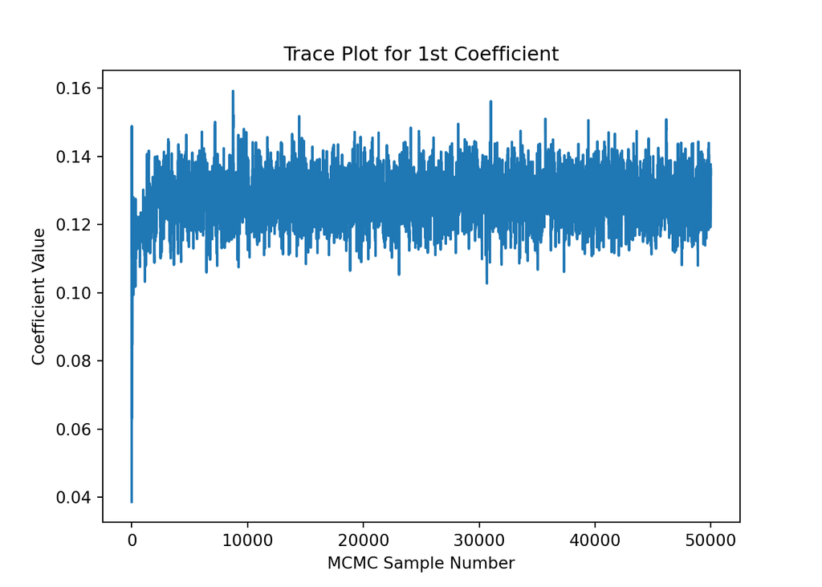

```python
plt.plot(bayes_mod.mcmc_params[:, 1])
plt.xlabel("MCMC Sample Number")
plt.ylabel("Coefficient Value")
plt.title("Trace Plot for 1st Coefficient")
plt.show()
```

```python
plt.figure()
```

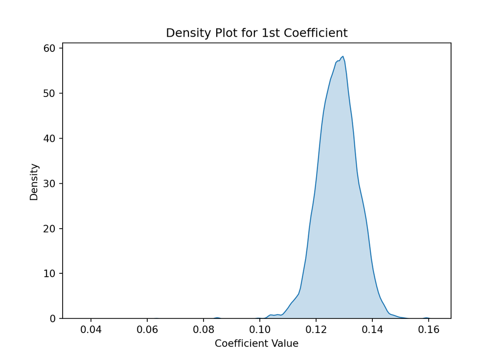

```python
sns.kdeplot(bayes_mod.mcmc_params[:, 1], shade=True)
plt.ylabel("Density")
plt.xlabel("Coefficient Value")
plt.title("Density Plot for 1st Coefficient")
plt.show()
```

### 2.2.3 BayesWeibullRegressor

Not yet implemented (coming soon)

## 2.3 tsdst.feature_selection

This module contains feature selection methods for machine learning or statistical models.

### 2.3.1 naiveVarDrop

Drop columns based on which columns have variance below the threshold.

```
Parameters
----------
X : pandas dataframe
    Feature (or design) matrix.
searchCols : list or list-like (str)
    The columns to search. If None, use all columns. Default is None.
tol : float, optional
    The threshold for variance to decide which columns to keep or drop.
    The default is 0.0001.
asList : bool, optional
    Return only the list of columns to be dropped. The default is False.
print_ : bool, optional
    Print the columns to be dropped. The default is False.

Returns
-------
list or dataframe
    Either list of columns to be dropped or dataframe with columns removed.
```

### 2.3.2 naiveScoreDrop

Drop columns based on which columns have scores below the threshold. This could be used with any arbitrary score function, where scores is a 1-column dataframe, in which the index are column names, and the values are the scores.

```
Parameters
----------
X : pandas dataframe
    Feature (or design) matrix.
scores : pandas dataframe
    The score results for each column.
tol : float, optional
    The threshold for variance to decide which columns to keep or drop.
    The default is 0.0001.
asList : bool, optional
    Return only the list of columns to be dropped. The default is False.

Returns
-------
list or dataframe
    Either list of columns to be dropped or dataframe with columns removed.
```

### 2.3.3 getHighCorrs

Given a correlation matrix, return the correlations that are above the threshold.

To be used before dropHighCorrs.

```
Parameters
----------
corr_mat : pandas dataframe
    The correlation matrix.
corr_thres : float
    The threshold for correlation to decide which columns to keep or drop.
    Between 0 and 1.
split_key : str, optional
    The unique key to use to join the column names together, for example,
    if split_key was '..&..', then the index for that correlation would be
    'col1..&..col2'. The default is "..&..".

Returns
-------
top_corr : pandas dataframe
    A dataframe containing a list of the top correlations from the
    correlation matrix.
```

### 2.3.4 dropHighCorrs

Remove high inter-correlations from the dataset. When dropping a column, the column with the lowest variance is selected.

To be used after getHighCorrs.

```
Parameters
----------
X : pandas dataframe
    The data in tabular form (the feature or design matrix of which the
    correlation is being evaluated).
top_corr : dataframe
    The output from the getHighCorrs function, or, a dataframe containing a
    list of the high correlations, where the index is a list of the column
    names concatenated together by split_key, for example, 'col1..&..col2'.
split_key : str, optional
    The unique key to use to join the column names together, for example,
    if split_key was '..&..', then the index for that correlation would be
    'col1..&..col2'. The default is "..&..".
asList : bool, optional
    Return only the list of columns to be dropped. The default is False.
print_ : bool, optional
    Print the columns to be dropped. The default is False.

Returns
-------
list or dataframe
    Either list of columns to be dropped or dataframe with columns removed.
```

### 2.3.5 dropCorrProcedure

Drops high correlation columns from a matrix. If two columns are highly correlated, it will pick one to keep based on which has higher variance.

Calculates the inter-correlation of the columns in a dataframe, and then drops columns that are above a given threshold.

```
Parameters
----------
X : pandas dataframe
    The data in tabular form (the feature or design matrix).
corr_thres : float
    The threshold for correlation to decide which columns to keep or drop.
    Between 0 and 1.
split_key : str, optional
    The unique key to use to join the column names together, for example,
    if split_key was '..&..', then the index for that correlation would be
    'col1..&..col2'. The default is "..&..".
asList : bool, optional
    Return only the list of columns to be dropped. The default is False.
print_ : bool, optional
    Print the columns to be dropped. The default is False.

Returns
-------
dropped_cor : dataframe
    Dataframe with High correlation columns dropped.
```

### 2.3.6 permutation_importance

Performs permutation importance on a fitted model.

Assumes that your metric function takes inputs in this order: ytrue, ypred. If it doesn’t, write a simple wrapper that will. Also assumes a pretrained model with a predict method.

Credit: [Explained AI](https://explained.ai/rf-importance/)

This function was adapted from the above link.

```
Parameters
----------
fit_model : sklearn, (or similar)
    Can be any model that has a 'predict' method.
Xtest : pandas Dataframe
    The observations in the feature or design matrix to perform the
    permutation test on.
Ytest : pandas Series
    The observations in the response variable to perform the
    permutation test on.
metric_func : function
    The function to evaluate your metric of interest.
seed : int, optional
    Set Random Seed for reporducibility. The default is None.
sort : str, optional
    Either 'asc' for ascending or 'dsc' for descending.
    The default is "dsc".

Returns
-------
res : dataframe
    A dataframe containing the results of the permutation test.
```

### 2.3.7 permutation_importance_CV

Performs a cross-validated permutation importance on a non-fitted model.

Assumes that your metric function takes inputs in this order: ytrue, ypred. If it doesn’t, write a simple wrapper that will. Also assumes a pretrained model with a predict method.

Credit: [Explained AI](https://explained.ai/rf-importance/)

This function was adapted from the above link.

```
Parameters
----------
model : sklearn, (or similar)
    Can be any model that has a 'predict' method. Send to the function
    unfitted, only instantiated
X : pandas Dataframe
    The observations in the feature or design matrix to perform the
    permutation test on.
Y : pandas Series
    The observations in the response variable to perform the
    permutation test on.
metric_func : function
    The function to evaluate your metric of interest.
num_splits : int
    Number of CV folds to use (using stratified k-fold)
seed : int, optional
    Set Random Seed for reporducibility. The default is None.
sort : str, optional
    Either 'asc' for ascending or 'dsc' for descending.
    The default is "dsc".

Returns
-------
res : dataframe
    A dataframe containing the results of the permutation test.
```

### 2.3.8 forwardSelection

A forward selection algorithm for classification only right now. Still needs some work.

```
Parameters
----------
XY : pandas dataframe
    The combined independent variables/features and reponse/target
    variable.
target_var : str
    The column containing the target (or response) variable.
model : sklearn, or similar
    An unfitted model. Any model that has a fit and predict method.
metric : str
    The AIC metric to be used, for example, aic, aicc, bic, ebic, hastie,
    or kwano.
verbose : bool, optional
    Output the steps and progress as it completes. The default is True.
n_jobs : int, optional
    If greater than 1, perform operation in parallel. The default is 1.
early_stop : bool, optional
    Stop operations early if max number of desired selection is reached.
    The default is False.
perc_min : TYPE, optional
    DESCRIPTION. The default is 0.05.
stop_at_p : int, optional
    The number of selections to stop at, if early_stop is True.
    The default is 1000.
stop_when : int, optional
    Stop the operations when the metric no longer continues to decrease,
    after evaluating the next stop_when columns. The default is 5.
use_probabilities : bool
    Whether or not to use predicted probabilities as the only other feature
    in the set, or to use the actual features in performing the forward
    selection.
return_type : str, optional
    Which object to return, can be either list, model, data, or all.
    The default is 'all'.
serialize_flavor : str
    Which mode of downsaving data to use, currently supports 'feather' and
    'msgpack'. Unfortunately, as of pandas 0.25.0, msgpack is no longer
    supported.

    Note: using feather requires pyarrow

Returns
-------
list, model, data, or tuple of objects
    Either return as list, model, data, or all. The default is 'all'.
```

```python
import numpy as np
import pandas as pd
import seaborn as sns
from matplotlib import pyplot as plt
from sklearn.datasets import make_classification
from sklearn.linear_model import LogisticRegression
from sklearn.model_selection import train_test_split
from timeit import default_timer as dt

from tsdst.feature_selection import forwardSelection


X, y = make_classification(n_samples=1000, n_features=8, flip_y=0.2, random_state=42)
X_train, X_test, y_train, y_test = train_test_split(X, y, test_size=0.2, random_state=42)
XY_train = pd.concat((pd.DataFrame(X_train, columns=['V' + str(i) for i in range(X.shape[1])]),
                      pd.DataFrame(y_train.reshape(-1, 1),
                                   columns=['y'])),
                      axis=1)

sk_mod = LogisticRegression(C=0.5)

forward_sel = forwardSelection(XY=XY_train, target_var='y', model=sk_mod,
                               metric='bic', verbose=True, n_jobs=1)
```

```
Problem Complexity: 36 Iterations Needed, 36 Possible...00:00:00 Current Time: 04:47:40 PM (Jul 30)


Percent: [#-------------------] 2.78% iter: 1/36 Working... Elapsed: 00:00:00, Estimated: 00:00:00
Percent: [#-------------------] 5.56% iter: 2/36 Working... Elapsed: 00:00:00, Estimated: 00:00:00
Percent: [##------------------] 8.33% iter: 3/36 Working... Elapsed: 00:00:00, Estimated: 00:00:00
Percent: [##------------------] 11.11% iter: 4/36 Working... Elapsed: 00:00:00, Estimated: 00:00:00
Percent: [###-----------------] 13.89% iter: 5/36 Working... Elapsed: 00:00:00, Estimated: 00:00:00
Percent: [###-----------------] 16.67% iter: 6/36 Working... Elapsed: 00:00:00, Estimated: 00:00:00
Percent: [####----------------] 19.44% iter: 7/36 Working... Elapsed: 00:00:00, Estimated: 00:00:00
Percent: [####----------------] 22.22% iter: 8/36 Working... Elapsed: 00:00:00, Estimated: 00:00:00
Percent: [#####---------------] 25.00% iter: 9/36 Working... Elapsed: 00:00:00, Estimated: 00:00:00
Percent: [######--------------] 27.78% iter: 10/36 Working... Elapsed: 00:00:00, Estimated: 00:00:00
Percent: [######--------------] 30.56% iter: 11/36 Working... Elapsed: 00:00:00, Estimated: 00:00:00
Percent: [#######-------------] 33.33% iter: 12/36 Working... Elapsed: 00:00:00, Estimated: 00:00:00
Percent: [#######-------------] 36.11% iter: 13/36 Working... Elapsed: 00:00:00, Estimated: 00:00:00
Percent: [########------------] 38.89% iter: 14/36 Working... Elapsed: 00:00:00, Estimated: 00:00:00
Percent: [########------------] 41.67% iter: 15/36 Working... Elapsed: 00:00:00, Estimated: 00:00:00
No further imporovement in the model. Breaking...
```

### 2.3.9 vif_drop

Coming soon.

## 2.4 tsdst.mcmc

A module for supporting MCMC evaluation capabilities, including an object to hold MCMC chains and store/compute useful metrics on them. It also includes some common plotting functionality.

The purpose of this class was to be a one-stop-shop for an MCMC chain. While algorithms or methods to produce or utilize chains may vary significantly, I have found that the methods to shape, trim, store, burn-in, or continue runs of a chain are easily generalized, and could be useful as a single class. The author is currently a proponent of the one-long-run ideology, so methods involving multiple chains are not currently considered.

To get a chain up and running, use the `runMCMC` method after instantiating the `mcmcObject` class.

```
Acceptance Rate:  0.1026
Number of Cholesky tries: 1
not enough samples in the chain for quantile 0.5. Could not evaluate.
Acceptance Rate:  0.22698
Number of Cholesky tries: 1
```

[figure not shown]

[figure not shown]

[figure not shown]

[figure not shown]

```python
import numpy as np
from scipy.stats import norm, invgamma
from tsdst.mcmc import mcmcObject, adaptive_mcmc


def gaussian_invGamma(params, data):
    '''
    A gaussian likelihood with a normal prior on mu, and an
    inverse-gamma prior on sigma.

    Parameters
    ----------
    params : numpy array
        The parameters of the distribution to be sampled in mcmc.
    data : numpy array
        The observed data.

    Returns
    -------
    log_post : float
        Log-Posterior density.
    '''
    mu = params[0]
    # sigma must be > 0, and params was sampled from a normal distribution,
    # so no guarantee it will be positive
    sigma = np.exp(params[1])

    like = np.sum(norm.logpdf(x=data, loc=mu, scale=sigma))

    # Weak Priors on both parameters
    norm_prior = np.sum(norm.logpdf(x=mu, loc=0, scale=100))
    invgamma_prior = np.sum(invgamma.logpdf(x=sigma, a=0.01, scale=100))

    # Since we are using a metropolis algorithm rather than metropolis-
    # hastings or another variant (i.e. candidate distribution is normal),
    # The Jacobian of any transformations used on the parameters must be
    # accounted for. The jacobian of an exponential transformation is
    # the log of the parameter.
    sigma_jac = params[1]

    log_post = like + norm_prior + invgamma_prior + sigma_jac
    return log_post


X = np.random.normal(size=(100,), loc=10, scale=3)
start = np.random.uniform(size=(2,))

normalExample = mcmcObject(name='Normal Example')
normalExample.runMCMC(start=start, initSampleSize=10000,
                      lpost=gaussian_invGamma, algo=adaptive_mcmc,
                      chainName='norm_example', plot_trace=False, plot_density=False,
                      plot_acf=False, do_raftery=True, iters_to_go=None,
                      max_iters=50000, burnin=0, lpost_args={'data': X},
                      algoOpts={'progress': False})
```

The `name` property is a name given to the object itself. Each chain is given it’s own unique name, usually denoted as `chainName`. An object can contain multiple chains, each with its own label, so instead of having multiple related class objects, one could instantiate one object and store multiple chains within that object.

The three dictionaries have similar properties. The `chains` property can store any given MCMC run as a key-value pair, where the chain name is the key and the chain itself is the value (see addChain or [mcmcWithRaftery] for more info). The `diagnostic_values` and `previous_values` properties store other information about the chain, which are the diagnostic tests and the ending values of the last run, respectively.

### 2.4.1 mcmcObject

This section contains methods relating to the `mcmcObject`.

#### 2.4.1.1 __init__

Constructor for MCMC object

```
Parameters
----------
name : str, optional
    The name of the object (in case you instantiate multiple objects).
    The default is "MCMC Object".

Returns
-------
None.
```

#### 2.4.1.2 addChain

This method adds a chain to the `chains` property. If no other name is provided, the default for chainName is ‘Chain_x,’ where ‘x’ is a number reflecting how many chains exist in the object. This function checks whether `newChain` is an object that can be converted to a numpy array, and if not already a numpy array, performs the conversion. Beyond that, it is up to the user to make sure what is being added has the right shape/size of your chain. If `concat` is set to true, it searches for a chain named `chainName`, and if found, appends `newChain` to the existing chain. Otherwise, a new chain is created.

```
Parameters
----------
newChain : numpy array
    New chain you would like to add to the collection.
chainName : str, optional
    The name of the added chain, used to seperate it from others in the
    collection. If None, one will be selected for you.
    The default is None.
concat : bool, optional
    Whether or not to append the new chain to an existing chain.
    The default is False.

Returns
-------
None.
```

```python
mcmcObject.addChain(newChain, chainName=None, concat=True)
```

#### 2.4.1.3 bestRaftery

This function is just a wrapper for raftery that performs the Raftery diagnostic for each value of `q`. The `print_each` and `print_final` functions will display the output of each run of raftery, as well as the combined result of all the runs. The combined result is simply the maximum of all the runs (see raftery for more details).

```
Parameters
----------
chainName : str
    The name of the chain from the collection.
q : float, optional
    Quantiles of interest (in terms of percentiles, i.e. between 0 and
                          1).
    The default is [0.025, 0.5, 0.975].
r : float, optional
    Accuracy. The default is 0.005.
s : float, optional
    Probability. The default is 0.95.
converge_eps : float, optional
    Convergence threshold (epsilon). The default is 0.001.
thin : int, optional
    Thining amount. The default is 1.
print_each : bool, optional
    Print results at each evaluation. The default is False.
print_final : bool, optional
    Print the final results. The default is False.

Returns
-------
None.
```

```python
bestRaftery(chainName, q=[0.025, 0.5, 0.975],
            r=0.005, s=0.90, converge_eps=0.001, thin=1,
            print_each=False, print_final=False)
```

#### 2.4.1.4 burnin

This method removes the first `burninVal` number of samples from the chain. The default is 3000.

Some people argue that burn-in is not necessary, or even practical, since the target distribution reflects a probability distribution where those burn-in values, no matter how unlikely, are still possible to obtain as valid samples. They argue that even a parameter value that has 0.0000001% chance of being drawn is still not zero, and therefore helps make up the target distribution. From another view, you can argue that if your chain is “long enough,” these values average out to be representative of the target distribution. However, the author believes that burn-in values are still useful for a similar reason. For example, it isn’t always possible to run really long chains (due to hardware or software constraints, the number of functions/objects needing MCMC samples, etc.). Therefore, if someone happen to get a chain that is mixing slowly (but after looking at the plots decided it did “converge” towards the end), then the quantiles of the sampled distribution with those burn-in values included will be different, and in that case the stationary distribution may not reflect the target distribution. Furthermore, if your chain is “long enough,” removing burn-in values should have little effect on the chain as a whole, and is likely to be more helpful then harmful.

```
Parameters
----------
chainName : str
    The name of the chain from the collection.
burninVal : int, optional
    The number of samples to remove. The default is 3000.
replace : bool
    If True, replace the current chain rather than create a new one
    without the burnin samples. If a new chain is created, it will
    be called chainName + '_burnin' + burnunVal, and will be available
    in the collection.

Returns
-------
None.
```

```python
burnin(chainName, burninVal=3000)
```

#### 2.4.1.5 runMCMC

This method is intended to perform a comprehensive run and diagnostic on the MCMC chain. The method performs an initial run using applyMCMC, which is supplied with starting values (`array start`), initial number of iterations (`int initSampleSize`), the posterior function (`func lpost`), the algorithm (`func algo`), algorithm options (`dict algoOpts`), options for bestRaftery (`dict raftOpts`), standard deviation for reassigning starting values during a retry (`float sd`), and the max number of retries (`int max_tries`). After the initial run completes, it adds the chain and it’s ending values to the `mcmcObject`. If `chainName` is not provided or is `None`, a default name is given. See the mcmcObject Algorithms section for MCMC algorithms and their options that can be passed to `algoOpts`

If `do_raftery=True`, then the method will perform a second MCMC run. If `iters_to_go=None`, then the second run will be performed with the remaining number of iterations as recommended by the Raftery functions. If the recommended number of samples is already reached in the initial chain, the second run will not be performed. Otherwise, the remaining iterations will be limited by the number `max_iters` or the Raftery output, whichever is smaller. The second run is initialized using the previous values of the first run.

After all MCMC runs have completed, the function checks for burn-in. If `burnin=None`, then no burn-in occurs. Otherwise, if `burnin=0`, the burn-in is calculated using the method TJ_Convergence_test, otherwise the value provided in `burnin` is used (note: burn-in removal from the chain occurs after plotting for display purposes).

The final step is plotting. If `plot_trace=True`, `plot_density=True`, or `plot_acf=True` then plots will be produced, and can either be written to a `jpg` file or printed to the console using the `write_plots` option. See plotDensity, plotTrace, or plotACF for more information.

The options for `raftOpts` are passed as a dictionary and are defined as follows:

| Option | Default Value | Type |
| --- | --- | --- |
| q | [0.025, 0.5, 0.975] | list(floats) |
| r | 0.005 | float |
| s | 0.95 | float |
| converge_eps | 0.001 | float |
| thin | 1 | int |
| print_each | FALSE | boolean |
| print_final | FALSE | boolean |

see tsdst.mcmc for a full example.

```
Parameters
----------
start : numpy array
    Starting values for the MCMC.
initSampleSize : int
    The number of MCMC samples to draw on the first run. It's good to
    start relatively small, because the Raftery evaluation will tell
    you how many more samples need to be drawn.
lpost : function
    Log posterior function.
algo : function
    The MCMC algorithm to use (could be anything, but needs to have the
same arguments as inputs for the algorithms already defined, namely:
    start : numpy array
        Starting values for the MCMC.
    niter : int
        Number of iterations.
    lpost : function
        Log posterior function.
    postArgs : dict
        Extra arguments for the log posterior function. The default is
        an empty dictionary
    options : dict, optional
        Extra arguments for the specific MCMC algorithm
algoOpts : dict, optional
    Extra arguments for the specific MCMC algorithm.
    The default is None.
raftOpts : dict, optional
    A dictionary containing the options for the Raftery evaluation,
    namely:
        q : float, optional
            Quantiles of interest (in terms of percentiles, i.e.
                                   between 0 and 1).
            The default is [0.025, 0.5, 0.975].
        r : float, optional
            Accuracy. The default is 0.005.
        s : float, optional
            Probability. The default is 0.95.
        converge_eps : float, optional
            Convergence threshold (epsilon). The default is 0.001.
```

[output cut: 44 more lines]

```
    evaluation recommends 1 million new samples, and max_iters is
    750000, then the new samples will be restricted at 750000.
    The default is 750000.
burnin : int, optional
    The number of initial MCMC samples to drop from the chain.
    If burnin is negative or zero, the burnin amount will be determined
    automatically. If positive, it will drop that amount. If
    None, it will do nothing. The default is 0.
lpost_args : dict, optional
    Any extra arguments to pass to the log posterior function.
    The default is an empty dictionary.

Returns
-------
None.
```

```python
runMCMC(self, start, initSampleSize, lpost, algo, algoOpts=None,
        raftOpts=None, chainName=None, max_tries=100, sd=0.02,
        plot_trace=True, plot_density=True, plot_acf=True,
        plot_trace_args=None, plot_density_args=None,
        plot_acf_args=None, acfType='pacf', acf_args=None,
        do_raftery=True, iters_to_go=None, max_iters=750000, burnin=0,
        lpost_args={})
```